# Lab 8 Output

[output not shown]

Log  
Log - Log - August 24, 2018

GET  
FILE='C:\Users\Heather\OneDrive - Brock University\Masters\Data\Final Masters Data Files\Working Copies\VanVolkenburgMSc_OCRIF_FieldSoilGLM_20180823.sav'.  
DATASET NAME DataSet1 WINDOW=FRONT.  
NEW FILE.  
DATASET NAME DataSet2 WINDOW=FRONT.  
DATASET ACTIVATE DataSet2.  
DATASET CLOSE DataSet1.  
GET  
FILE='C:\Users\Heather\Desktop\R CSV Data\Biometrics\SPSS files\SPSS files\maternal role adaptation.sav'.  
DATASET NAME DataSet3 WINDOW=FRONT.  
DATASET CLOSE DataSet2.  
ONEWAY Adapt BY Group  
/STATISTICS DESCRIPTIVES HOMOGENEITY  
/PLOT MEANS  
/MISSING ANALYSIS  
/POSTHOC=TUKEY ALPHA(0.05).

Oneway  
Oneway - Descriptives - August 24, 2018

DescriptivesDescriptives, table, Adapt, 1 layers, 2 levels of column headers and 1 levels of row headers, table with 9 columns and 8 rows

| Adapt Adapt |  |  |  |  |  |  |  |  |  |  |
| --- | --- | --- | --- | --- | --- | --- | --- | --- | --- | --- |
|  | N | Mean | Std. Deviation | Std. Error | 95% Confidence Interval for Mean |  | Minimum | Maximum |  |  |
|  |  |  |  |  | Lower Bound | Upper Bound |  |  |  |  |
| LBW-Exp | 29 | 13.00 | 2.345 | .435 | 12.11 | 13.89 |  |  | 9 | 18 |
| LBW-Control | 27 | 19.59 | 3.165 | .609 | 18.34 | 20.84 | 14 | 26 |  |  |
| Full-Term | 37 | 14.16 | 2.713 | .446 | 13.26 | 15.07 | 10 | 20 |  |  |
| Total | 93 | 15.38 | 3.870 | .401 | 14.58 | 16.17 | 9 | 26 |  |  |

Oneway  
Oneway - Test of Homogeneity of Variances - August 24, 2018

Test of Homogeneity of VariancesTest of Homogeneity of Variances, table, Adapt, 1 layers, 1 levels of column headers and 0 levels of row headers, table with 4 columns and 4 rows

| Adapt Adapt |  |  |  |
| --- | --- | --- | --- |
| Levene Statistic | df1 | df2 | Sig. |
| 1.556 | 2 | 90 | .217 |

Oneway  
Oneway - ANOVA - August 24, 2018

ANOVAANOVA, table, Adapt, 1 layers, 1 levels of column headers and 1 levels of row headers, table with 6 columns and 6 rows

| Adapt Adapt |  |  |  |  |  |
| --- | --- | --- | --- | --- | --- |
|  | Sum of Squares | df | Mean Square | F | Sig. |
| Between Groups | 698.282 | 2 | 349.141 | 46.241 | .000 |
| Within Groups | 679.546 | 90 | 7.551 |  |  |
| Total | 1377.828 | 92 |  |  |  |

Post Hoc Tests  
Post Hoc Tests - Multiple Comparisons - August 24, 2018

Multiple ComparisonsMultiple Comparisons, table, Dependent Variable, Adapt, Tukey HSD, 1 layers, 2 levels of column headers and 2 levels of row headers, table with 7 columns and 12 rows

| Adapt Adapt Tukey HSD Tukey HSD |  |  |  |  |  |  |
| --- | --- | --- | --- | --- | --- | --- |
| (I) Group | (J) Group | Mean Difference (I-J) | Std. Error | Sig. | 95% Confidence Interval |  |
|  |  |  |  |  | Lower Bound | Upper Bound |
| LBW-Exp | LBW-Control | -6.593* | .735 | .000 | -8.34 | -4.84 |
|  | Full-Term | -1.162 | .681 | .209 | -2.79 | .46 |
| LBW-Control | LBW-Exp | 6.593* | .735 | .000 | 4.84 | 8.34 |
|  | Full-Term | 5.430* | .695 | .000 | 3.77 | 7.09 |
| Full-Term | LBW-Exp | 1.162 | .681 | .209 | -.46 | 2.79 |
|  | LBW-Control | -5.430* | .695 | .000 | -7.09 | -3.77 |

*. The mean difference is significant at the 0.05 level.

Homogeneous Subsets  
Homogeneous Subsets - Adapt - August 24, 2018

AdaptAdapt, table, Tukey HSD, 1 layers, 2 levels of column headers and 1 levels of row headers, table with 4 columns and 11 rows

| Tukey HSD<sup>a,b</sup> Tukey HSD<sup>a,b</sup> |  |  |  |
| --- | --- | --- | --- |
| Group | N | Subset for alpha = 0.05 |  |
|  |  | 1 | 2 |
| LBW-Exp | 29 | 13.00 |  |
| Full-Term | 37 | 14.16 |  |
| LBW-Control | 27 |  | 19.59 |
| Sig. |  | .230 | 1.000 |

Means for groups in homogeneous subsets are displayed.  
a. Uses Harmonic Mean Sample Size = 30.442.  
b. The group sizes are unequal. The harmonic mean of the group sizes is used. Type I error levels are not guaranteed.

Means Plots  
Means Plots - Adapt - August 24, 2018

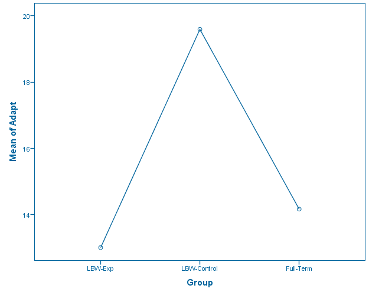

Log  
Log - Log - August 24, 2018

GET  
FILE='C:\Users\Heather\Desktop\R CSV Data\Biometrics\SPSS files\SPSS files\Knees circadian clock.sav'.  
>Warning # 5281. Command name: GET FILE  
>SPSS Statistics is running in Unicode encoding mode. This file is encoded in  
>a locale-specific (code page) encoding. The defined width of any string  
>variables are automatically tripled in order to avoid possible data loss. You  
>can use ALTER TYPE to set the width of string variables to the width of the  
>longest observed value for each string variable.  
DATASET NAME DataSet4 WINDOW=FRONT.  
ONEWAY shift BY treatment  
/STATISTICS DESCRIPTIVES HOMOGENEITY  
/PLOT MEANS  
/MISSING ANALYSIS  
/POSTHOC=TUKEY ALPHA(0.05).

Oneway  
Oneway - Active Dataset - August 24, 2018

[DataSet4] C:\Users\Heather\Desktop\R CSV Data\Biometrics\SPSS files\SPSS files\Knees circadian clock.sav

Oneway  
Oneway - Descriptives - August 24, 2018

DescriptivesDescriptives, table, shift, 1 layers, 2 levels of column headers and 1 levels of row headers, table with 9 columns and 8 rows

| shift shift |  |  |  |  |  |  |  |  |  |  |
| --- | --- | --- | --- | --- | --- | --- | --- | --- | --- | --- |
|  | N | Mean | Std. Deviation | Std. Error | 95% Confidence Interval for Mean |  | Minimum | Maximum |  |  |
|  |  |  |  |  | Lower Bound | Upper Bound |  |  |  |  |
| Control | 8 | -.3087 | .61756 | .21834 | -.8250 | .2075 |  |  | -1.27 | .53 |
| Knees | 7 | -.3357 | .79082 | .29890 | -1.0671 | .3957 | -1.61 | .73 |  |  |
| Eyes | 7 | -1.5514 | .70632 | .26696 | -2.2047 | -.8982 | -2.83 | -.78 |  |  |
| Total | 22 | -.7127 | .89015 | .18978 | -1.1074 | -.3181 | -2.83 | .73 |  |  |

Oneway  
Oneway - Test of Homogeneity of Variances - August 24, 2018

Test of Homogeneity of VariancesTest of Homogeneity of Variances, table, shift, 1 layers, 1 levels of column headers and 0 levels of row headers, table with 4 columns and 4 rows

| shift shift |  |  |  |
| --- | --- | --- | --- |
| Levene Statistic | df1 | df2 | Sig. |
| .156 | 2 | 19 | .856 |

Oneway  
Oneway - ANOVA - August 24, 2018

ANOVAANOVA, table, shift, 1 layers, 1 levels of column headers and 1 levels of row headers, table with 6 columns and 6 rows

| shift shift |  |  |  |  |  |
| --- | --- | --- | --- | --- | --- |
|  | Sum of Squares | df | Mean Square | F | Sig. |
| Between Groups | 7.224 | 2 | 3.612 | 7.289 | .004 |
| Within Groups | 9.415 | 19 | .496 |  |  |
| Total | 16.640 | 21 |  |  |  |

Post Hoc Tests  
Post Hoc Tests - Multiple Comparisons - August 24, 2018

Multiple ComparisonsMultiple Comparisons, table, Dependent Variable, shift, Tukey HSD, 1 layers, 2 levels of column headers and 2 levels of row headers, table with 7 columns and 12 rows

| shift shift Tukey HSD Tukey HSD |  |  |  |  |  |  |
| --- | --- | --- | --- | --- | --- | --- |
| (I) treatment | (J) treatment | Mean Difference (I-J) | Std. Error | Sig. | 95% Confidence Interval |  |
|  |  |  |  |  | Lower Bound | Upper Bound |
| Control | Knees | .02696 | .36433 | .997 | -.8986 | .9525 |
|  | Eyes | 1.24268* | .36433 | .008 | .3171 | 2.1682 |
| Knees | Control | -.02696 | .36433 | .997 | -.9525 | .8986 |
|  | Eyes | 1.21571* | .37628 | .012 | .2598 | 2.1716 |
| Eyes | Control | -1.24268* | .36433 | .008 | -2.1682 | -.3171 |
|  | Knees | -1.21571* | .37628 | .012 | -2.1716 | -.2598 |

*. The mean difference is significant at the 0.05 level.

Homogeneous Subsets  
Homogeneous Subsets - shift - August 24, 2018

shiftshift, table, Tukey HSD, 1 layers, 2 levels of column headers and 1 levels of row headers, table with 4 columns and 11 rows

| Tukey HSD<sup>a,b</sup> Tukey HSD<sup>a,b</sup> |  |  |  |
| --- | --- | --- | --- |
| treatment | N | Subset for alpha = 0.05 |  |
|  |  | 1 | 2 |
| Eyes | 7 | -1.5514 |  |
| Knees | 7 |  | -.3357 |
| Control | 8 |  | -.3087 |
| Sig. |  | 1.000 | .997 |

Means for groups in homogeneous subsets are displayed.  
a. Uses Harmonic Mean Sample Size = 7.304.  
b. The group sizes are unequal. The harmonic mean of the group sizes is used. Type I error levels are not guaranteed.

Means Plots  
Means Plots - shift - August 24, 2018

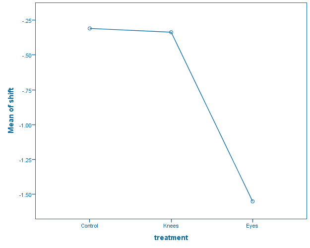

Log  
Log - Log - August 24, 2018

GET  
FILE='C:\Users\Heather\Desktop\R CSV Data\Biometrics\SPSS files\SPSS files\Recall.sav'.  
DATASET NAME DataSet5 WINDOW=FRONT.  
ONEWAY Recall BY Group  
/STATISTICS DESCRIPTIVES HOMOGENEITY  
/PLOT MEANS  
/MISSING ANALYSIS  
/POSTHOC=TUKEY ALPHA(0.05).

Oneway  
Oneway - Active Dataset - August 24, 2018

[DataSet5] C:\Users\Heather\Desktop\R CSV Data\Biometrics\SPSS files\SPSS files\Recall.sav

Oneway  
Oneway - Descriptives - August 24, 2018

DescriptivesDescriptives, table, Recall, 1 layers, 2 levels of column headers and 1 levels of row headers, table with 9 columns and 10 rows

| Recall Recall |  |  |  |  |  |  |  |  |  |  |
| --- | --- | --- | --- | --- | --- | --- | --- | --- | --- | --- |
|  | N | Mean | Std. Deviation | Std. Error | 95% Confidence Interval for Mean |  | Minimum | Maximum |  |  |
|  |  |  |  |  | Lower Bound | Upper Bound |  |  |  |  |
| Counting | 10 | 7.0000 | 1.82574 | .57735 | 5.6939 | 8.3061 |  |  | 4.00 | 10.00 |
| Rhyming | 10 | 6.9000 | 2.13177 | .67412 | 5.3750 | 8.4250 | 3.00 | 11.00 |  |  |
| Adjective | 10 | 11.0000 | 2.49444 | .78881 | 9.2156 | 12.7844 | 6.00 | 14.00 |  |  |
| Imagery | 10 | 12.7000 | 3.19896 | 1.01160 | 10.4116 | 14.9884 | 9.00 | 19.00 |  |  |
| Intentional | 10 | 12.0000 | 3.74166 | 1.18322 | 9.3234 | 14.6766 | 5.00 | 19.00 |  |  |
| Total | 50 | 9.9200 | 3.65245 | .51653 | 8.8820 | 10.9580 | 3.00 | 19.00 |  |  |

Oneway  
Oneway - Test of Homogeneity of Variances - August 24, 2018

Test of Homogeneity of VariancesTest of Homogeneity of Variances, table, Recall, 1 layers, 1 levels of column headers and 0 levels of row headers, table with 4 columns and 4 rows

| Recall Recall |  |  |  |
| --- | --- | --- | --- |
| Levene Statistic | df1 | df2 | Sig. |
| 1.456 | 4 | 45 | .231 |

Oneway  
Oneway - ANOVA - August 24, 2018

ANOVAANOVA, table, Recall, 1 layers, 1 levels of column headers and 1 levels of row headers, table with 6 columns and 6 rows

| Recall Recall |  |  |  |  |  |
| --- | --- | --- | --- | --- | --- |
|  | Sum of Squares | df | Mean Square | F | Sig. |
| Between Groups | 308.680 | 4 | 77.170 | 10.066 | .000 |
| Within Groups | 345.000 | 45 | 7.667 |  |  |
| Total | 653.680 | 49 |  |  |  |

Post Hoc Tests  
Post Hoc Tests - Multiple Comparisons - August 24, 2018

Multiple ComparisonsMultiple Comparisons, table, Dependent Variable, Recall, Tukey HSD, 1 layers, 2 levels of column headers and 2 levels of row headers, table with 7 columns and 26 rows

| Recall Recall Tukey HSD Tukey HSD |  |  |  |  |  |  |
| --- | --- | --- | --- | --- | --- | --- |
| (I) Group | (J) Group | Mean Difference (I-J) | Std. Error | Sig. | 95% Confidence Interval |  |
|  |  |  |  |  | Lower Bound | Upper Bound |
| Counting | Rhyming | .10000 | 1.23828 | 1.000 | -3.4185 | 3.6185 |
|  | Adjective | -4.00000* | 1.23828 | .019 | -7.5185 | -.4815 |
|  | Imagery | -5.70000* | 1.23828 | .000 | -9.2185 | -2.1815 |
|  | Intentional | -5.00000* | 1.23828 | .002 | -8.5185 | -1.4815 |
| Rhyming | Counting | -.10000 | 1.23828 | 1.000 | -3.6185 | 3.4185 |
|  | Adjective | -4.10000* | 1.23828 | .015 | -7.6185 | -.5815 |
|  | Imagery | -5.80000* | 1.23828 | .000 | -9.3185 | -2.2815 |
|  | Intentional | -5.10000* | 1.23828 | .001 | -8.6185 | -1.5815 |
| Adjective | Counting | 4.00000* | 1.23828 | .019 | .4815 | 7.5185 |
|  | Rhyming | 4.10000* | 1.23828 | .015 | .5815 | 7.6185 |
|  | Imagery | -1.70000 | 1.23828 | .648 | -5.2185 | 1.8185 |
|  | Intentional | -1.00000 | 1.23828 | .927 | -4.5185 | 2.5185 |
| Imagery | Counting | 5.70000* | 1.23828 | .000 | 2.1815 | 9.2185 |
|  | Rhyming | 5.80000* | 1.23828 | .000 | 2.2815 | 9.3185 |
|  | Adjective | 1.70000 | 1.23828 | .648 | -1.8185 | 5.2185 |
|  | Intentional | .70000 | 1.23828 | .979 | -2.8185 | 4.2185 |
| Intentional | Counting | 5.00000* | 1.23828 | .002 | 1.4815 | 8.5185 |
|  | Rhyming | 5.10000* | 1.23828 | .001 | 1.5815 | 8.6185 |
|  | Adjective | 1.00000 | 1.23828 | .927 | -2.5185 | 4.5185 |
|  | Imagery | -.70000 | 1.23828 | .979 | -4.2185 | 2.8185 |

*. The mean difference is significant at the 0.05 level.

Homogeneous Subsets  
Homogeneous Subsets - Recall - August 24, 2018

RecallRecall, table, Tukey HSD, 1 layers, 2 levels of column headers and 1 levels of row headers, table with 4 columns and 12 rows

| Tukey HSD<sup>a</sup> Tukey HSD<sup>a</sup> |  |  |  |
| --- | --- | --- | --- |
| Group | N | Subset for alpha = 0.05 |  |
|  |  | 1 | 2 |
| Rhyming | 10 | 6.9000 |  |
| Counting | 10 | 7.0000 |  |
| Adjective | 10 |  | 11.0000 |
| Intentional | 10 |  | 12.0000 |
| Imagery | 10 |  | 12.7000 |
| Sig. |  | 1.000 | .648 |

Means for groups in homogeneous subsets are displayed.  
a. Uses Harmonic Mean Sample Size = 10.000.

Means Plots  
Means Plots - Recall - August 24, 2018

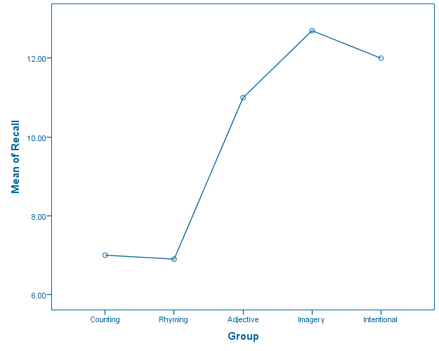

Log  
Log - Log - August 24, 2018

GET  
FILE='C:\Users\Heather\Desktop\R CSV Data\Biometrics\SPSS files\SPSS files\Cuckoo eggs.sav'.  
DATASET NAME DataSet6 WINDOW=FRONT.  
ONEWAY EggLength BY HostSpecies  
/STATISTICS DESCRIPTIVES HOMOGENEITY  
/PLOT MEANS  
/MISSING ANALYSIS  
/POSTHOC=TUKEY ALPHA(0.05).

Oneway  
Oneway - Active Dataset - August 24, 2018

[DataSet6] C:\Users\Heather\Desktop\R CSV Data\Biometrics\SPSS files\SPSS files\Cuckoo eggs.sav

Oneway  
Oneway - Descriptives - August 24, 2018

DescriptivesDescriptives, table, EggLength, 1 layers, 2 levels of column headers and 1 levels of row headers, table with 9 columns and 11 rows

| EggLength EggLength |  |  |  |  |  |  |  |  |  |  |
| --- | --- | --- | --- | --- | --- | --- | --- | --- | --- | --- |
|  | N | Mean | Std. Deviation | Std. Error | 95% Confidence Interval for Mean |  | Minimum | Maximum |  |  |
|  |  |  |  |  | Lower Bound | Upper Bound |  |  |  |  |
| Hedge Sparrow | 14 | 23.1214 | 1.06874 | .28563 | 22.5044 | 23.7385 |  |  | 20.85 | 25.05 |
| Meadow Pipit | 30 | 22.1733 | 1.02442 | .18703 | 21.7908 | 22.5559 | 19.65 | 24.45 |  |  |
| Pied Wagtail | 15 | 22.9033 | 1.06762 | .27566 | 22.3121 | 23.4946 | 21.05 | 24.85 |  |  |
| Robin | 16 | 22.5750 | .68459 | .17115 | 22.2102 | 22.9398 | 21.05 | 23.85 |  |  |
| Tree Pipit | 15 | 23.0900 | .90143 | .23275 | 22.5908 | 23.5892 | 21.05 | 24.05 |  |  |
| Wren | 15 | 21.1300 | .74374 | .19203 | 20.7181 | 21.5419 | 19.85 | 22.25 |  |  |
| Total | 105 | 22.4471 | 1.12493 | .10978 | 22.2294 | 22.6648 | 19.65 | 25.05 |  |  |

Oneway  
Oneway - Test of Homogeneity of Variances - August 24, 2018

Test of Homogeneity of VariancesTest of Homogeneity of Variances, table, EggLength, 1 layers, 1 levels of column headers and 0 levels of row headers, table with 4 columns and 4 rows

| EggLength EggLength |  |  |  |
| --- | --- | --- | --- |
| Levene Statistic | df1 | df2 | Sig. |
| .629 | 5 | 99 | .678 |

Oneway  
Oneway - ANOVA - August 24, 2018

ANOVAANOVA, table, EggLength, 1 layers, 1 levels of column headers and 1 levels of row headers, table with 6 columns and 6 rows

| EggLength EggLength |  |  |  |  |  |
| --- | --- | --- | --- | --- | --- |
|  | Sum of Squares | df | Mean Square | F | Sig. |
| Between Groups | 44.220 | 5 | 8.844 | 10.019 | .000 |
| Within Groups | 87.390 | 99 | .883 |  |  |
| Total | 131.609 | 104 |  |  |  |

Post Hoc Tests  
Post Hoc Tests - Multiple Comparisons - August 24, 2018

Multiple ComparisonsMultiple Comparisons, table, Dependent Variable, EggLength, Tukey HSD, 1 layers, 2 levels of column headers and 2 levels of row headers, table with 7 columns and 36 rows

| EggLength EggLength Tukey HSD Tukey HSD |  |  |  |  |  |  |
| --- | --- | --- | --- | --- | --- | --- |
| (I) HostSpecies | (J) HostSpecies | Mean Difference (I-J) | Std. Error | Sig. | 95% Confidence Interval |  |
|  |  |  |  |  | Lower Bound | Upper Bound |
| Hedge Sparrow | Meadow Pipit | .94810* | .30410 | .028 | .0643 | 1.8319 |
|  | Pied Wagtail | .21810 | .34914 | .989 | -.7966 | 1.2328 |
|  | Robin | .54643 | .34383 | .608 | -.4529 | 1.5457 |
|  | Tree Pipit | .03143 | .34914 | 1.000 | -.9833 | 1.0461 |
|  | Wren | 1.99143* | .34914 | .000 | .9767 | 3.0061 |
| Meadow Pipit | Hedge Sparrow | -.94810* | .30410 | .028 | -1.8319 | -.0643 |
|  | Pied Wagtail | -.73000 | .29711 | .147 | -1.5935 | .1335 |
|  | Robin | -.40167 | .29085 | .738 | -1.2470 | .4436 |
|  | Tree Pipit | -.91667* | .29711 | .031 | -1.7801 | -.0532 |
|  | Wren | 1.04333* | .29711 | .009 | .1799 | 1.9068 |
| Pied Wagtail | Hedge Sparrow | -.21810 | .34914 | .989 | -1.2328 | .7966 |
|  | Meadow Pipit | .73000 | .29711 | .147 | -.1335 | 1.5935 |
|  | Robin | .32833 | .33767 | .926 | -.6530 | 1.3097 |
|  | Tree Pipit | -.18667 | .34307 | .994 | -1.1837 | .8104 |
|  | Wren | 1.77333* | .34307 | .000 | .7763 | 2.7704 |
| Robin | Hedge Sparrow | -.54643 | .34383 | .608 | -1.5457 | .4529 |
|  | Meadow Pipit | .40167 | .29085 | .738 | -.4436 | 1.2470 |
|  | Pied Wagtail | -.32833 | .33767 | .926 | -1.3097 | .6530 |
|  | Tree Pipit | -.51500 | .33767 | .649 | -1.4964 | .4664 |
|  | Wren | 1.44500* | .33767 | .001 | .4636 | 2.4264 |
| Tree Pipit | Hedge Sparrow | -.03143 | .34914 | 1.000 | -1.0461 | .9833 |
|  | Meadow Pipit | .91667* | .29711 | .031 | .0532 | 1.7801 |
|  | Pied Wagtail | .18667 | .34307 | .994 | -.8104 | 1.1837 |
|  | Robin | .51500 | .33767 | .649 | -.4664 | 1.4964 |
|  | Wren | 1.96000* | .34307 | .000 | .9629 | 2.9571 |
| Wren | Hedge Sparrow | -1.99143* | .34914 | .000 | -3.0061 | -.9767 |
|  | Meadow Pipit | -1.04333* | .29711 | .009 | -1.9068 | -.1799 |
|  | Pied Wagtail | -1.77333* | .34307 | .000 | -2.7704 | -.7763 |
|  | Robin | -1.44500* | .33767 | .001 | -2.4264 | -.4636 |
|  | Tree Pipit | -1.96000* | .34307 | .000 | -2.9571 | -.9629 |

*. The mean difference is significant at the 0.05 level.

Homogeneous Subsets  
Homogeneous Subsets - EggLength - August 24, 2018

EggLengthEggLength, table, Tukey HSD, 1 layers, 2 levels of column headers and 1 levels of row headers, table with 4 columns and 14 rows

| Tukey HSD<sup>a,b</sup> Tukey HSD<sup>a,b</sup> |  |  |  |
| --- | --- | --- | --- |
| HostSpecies | N | Subset for alpha = 0.05 |  |
|  |  | 1 | 2 |
| Wren | 15 | 21.1300 |  |
| Meadow Pipit | 30 |  | 22.1733 |
| Robin | 16 |  | 22.5750 |
| Pied Wagtail | 15 |  | 22.9033 |
| Tree Pipit | 15 |  | 23.0900 |
| Hedge Sparrow | 14 |  | 23.1214 |
| Sig. |  | 1.000 | .053 |

Means for groups in homogeneous subsets are displayed.  
a. Uses Harmonic Mean Sample Size = 16.337.  
b. The group sizes are unequal. The harmonic mean of the group sizes is used. Type I error levels are not guaranteed.

Means Plots  
Means Plots - EggLength - August 24, 2018

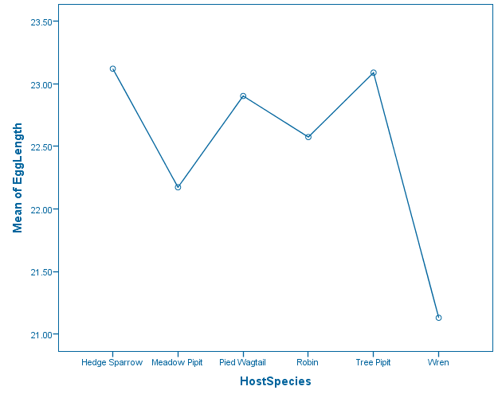

Log  
Log - Log - August 24, 2018

GET  
FILE='C:\Users\Heather\Desktop\R CSV Data\Biometrics\SPSS files\SPSS files\Malaria maize.sav'.  
DATASET NAME DataSet7 WINDOW=FRONT.  
*Nonparametric Tests: Independent Samples.  
NPTESTS  
/INDEPENDENT TEST (Incidencerate10000) GROUP (Maizeyield) KRUSKAL_WALLIS(COMPARE=PAIRWISE)  
/MISSING SCOPE=ANALYSIS USERMISSING=EXCLUDE  
/CRITERIA ALPHA=0.05 CILEVEL=95.

Nonparametric Tests  
Nonparametric Tests - Active Dataset - August 24, 2018

[DataSet7] C:\Users\Heather\Desktop\R CSV Data\Biometrics\SPSS files\SPSS files\Malaria maize.sav

Nonparametric Tests  
Tables from the Model Viewer cannot be edited: Nonparametric Tests - Model Viewer - August 24, 2018

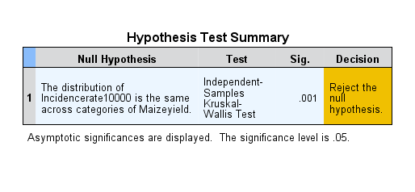

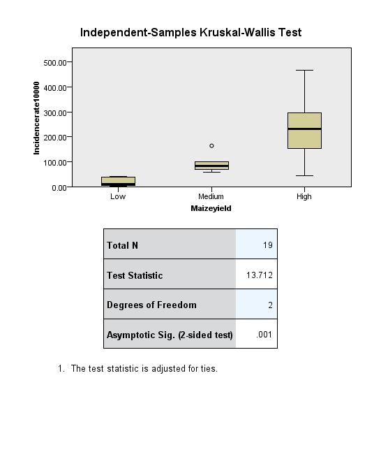

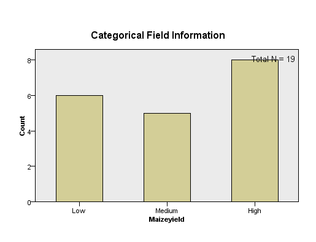

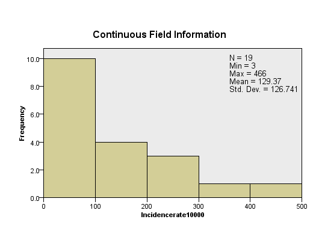

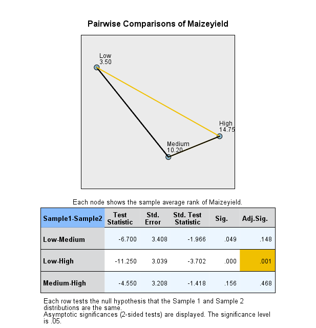

Log  
Log - Log - August 24, 2018

GET  
FILE='C:\Users\Heather\Desktop\R CSV Data\Biometrics\SPSS files\SPSS files\nematode.sav'.  
>Warning # 5281. Command name: GET FILE  
>SPSS Statistics is running in Unicode encoding mode. This file is encoded in  
>a locale-specific (code page) encoding. The defined width of any string  
>variables are automatically tripled in order to avoid possible data loss. You  
>can use ALTER TYPE to set the width of string variables to the width of the  
>longest observed value for each string variable.  
DATASET NAME DataSet8 WINDOW=FRONT.  
EXAMINE VARIABLES=lifespan BY treatment  
/PLOT BOXPLOT NPPLOT  
/COMPARE GROUPS  
/STATISTICS DESCRIPTIVES  
/CINTERVAL 95  
/MISSING LISTWISE  
/NOTOTAL.

Explore  
Explore - Active Dataset - August 24, 2018

[DataSet8] C:\Users\Heather\Desktop\R CSV Data\Biometrics\SPSS files\SPSS files\nematode.sav

treatment  
treatment - Case Processing Summary - August 24, 2018

Case Processing SummaryCase Processing Summary, table, 3 levels of column headers and 2 levels of row headers, table with 8 columns and 8 rows

|  | treatment | Cases |  |  |  |  |  |
| --- | --- | --- | --- | --- | --- | --- | --- |
|  |  | Valid |  | Missing |  | Total |  |
|  |  | N | Percent | N | Percent | N | Percent |
| lifespan | water | 50 | 100.0% | 0 | 0.0% | 50 | 100.0% |
|  | treatment at both stages | 50 | 100.0% | 0 | 0.0% | 50 | 100.0% |
|  | larva treatment | 50 | 100.0% | 0 | 0.0% | 50 | 100.0% |
|  | adult treatment | 50 | 100.0% | 0 | 0.0% | 50 | 100.0% |

treatment  
treatment - Descriptives - August 24, 2018

DescriptivesDescriptives, table, 1 levels of column headers and 4 levels of row headers, table with 6 columns and 54 rows

|  | treatment |  |  | Statistic | Std. Error |
| --- | --- | --- | --- | --- | --- |
| lifespan | water | Mean |  | 16.34 | .485 |
|  |  | 95% Confidence Interval for Mean | Lower Bound | 15.36 |  |
|  |  |  | Upper Bound | 17.32 |  |
|  |  | 5% Trimmed Mean |  | 16.31 |  |
|  |  | Median |  | 16.00 |  |
|  |  | Variance |  | 11.780 |  |
|  |  | Std. Deviation |  | 3.432 |  |
|  |  | Minimum |  | 6 |  |
|  |  | Maximum |  | 28 |  |
|  |  | Range |  | 22 |  |
|  |  | Interquartile Range |  | 4 |  |
|  |  | Skewness |  | .288 | .337 |
|  |  | Kurtosis |  | 2.800 | .662 |
|  | treatment at both stages | Mean |  | 22.22 | 1.224 |
|  |  | 95% Confidence Interval for Mean | Lower Bound | 19.76 |  |
|  |  |  | Upper Bound | 24.68 |  |
|  |  | 5% Trimmed Mean |  | 22.18 |  |
|  |  | Median |  | 24.50 |  |
|  |  | Variance |  | 74.910 |  |
|  |  | Std. Deviation |  | 8.655 |  |
|  |  | Minimum |  | 8 |  |
|  |  | Maximum |  | 36 |  |
|  |  | Range |  | 28 |  |
|  |  | Interquartile Range |  | 17 |  |
|  |  | Skewness |  | -.234 | .337 |
|  |  | Kurtosis |  | -1.340 | .662 |
|  | larva treatment | Mean |  | 15.38 | .468 |
|  |  | 95% Confidence Interval for Mean | Lower Bound | 14.44 |  |
|  |  |  | Upper Bound | 16.32 |  |
|  |  | 5% Trimmed Mean |  | 15.33 |  |
|  |  | Median |  | 16.00 |  |
|  |  | Variance |  | 10.934 |  |
|  |  | Std. Deviation |  | 3.307 |  |
|  |  | Minimum |  | 10 |  |
|  |  | Maximum |  | 22 |  |
|  |  | Range |  | 12 |  |
|  |  | Interquartile Range |  | 6 |  |
|  |  | Skewness |  | -.032 | .337 |
|  |  | Kurtosis |  | -.842 | .662 |
|  | adult treatment | Mean |  | 20.54 | .936 |
|  |  | 95% Confidence Interval for Mean | Lower Bound | 18.66 |  |
|  |  |  | Upper Bound | 22.42 |  |
|  |  | 5% Trimmed Mean |  | 20.68 |  |
|  |  | Median |  | 22.00 |  |
|  |  | Variance |  | 43.764 |  |
|  |  | Std. Deviation |  | 6.615 |  |
|  |  | Minimum |  | 8 |  |
|  |  | Maximum |  | 32 |  |
|  |  | Range |  | 24 |  |
|  |  | Interquartile Range |  | 11 |  |
|  |  | Skewness |  | -.440 | .337 |
|  |  | Kurtosis |  | -.842 | .662 |

treatment  
treatment - Tests of Normality - August 24, 2018

Tests of NormalityTests of Normality, table, 2 levels of column headers and 2 levels of row headers, table with 8 columns and 8 rows

|  | treatment | Kolmogorov-Smirnov<sup>a</sup> |  |  | Shapiro-Wilk |  |  |
| --- | --- | --- | --- | --- | --- | --- | --- |
|  |  | Statistic | df | Sig. | Statistic | df | Sig. |
| lifespan | water | .139 | 50 | .016 | .940 | 50 | .013 |
|  | treatment at both stages | .168 | 50 | .001 | .907 | 50 | .001 |
|  | larva treatment | .154 | 50 | .004 | .949 | 50 | .031 |
|  | adult treatment | .127 | 50 | .042 | .941 | 50 | .015 |

a. Lilliefors Significance Correction

Normal Q-Q Plots  
Normal Q-Q Plots - treatment= water - August 24, 2018

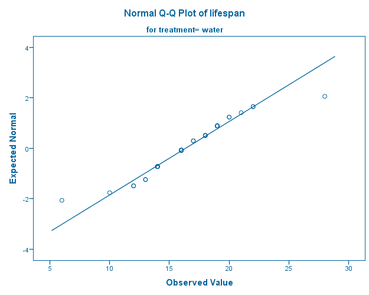

Normal Q-Q Plots  
Normal Q-Q Plots - treatment= treatment at both stages - August 24, 2018

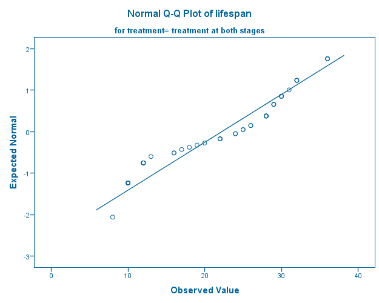

Normal Q-Q Plots  
Normal Q-Q Plots - treatment= larva treatment - August 24, 2018

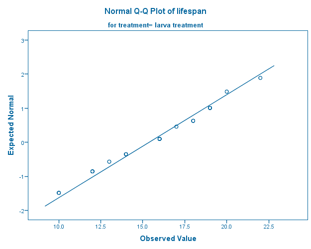

Normal Q-Q Plots  
Normal Q-Q Plots - treatment= adult treatment - August 24, 2018

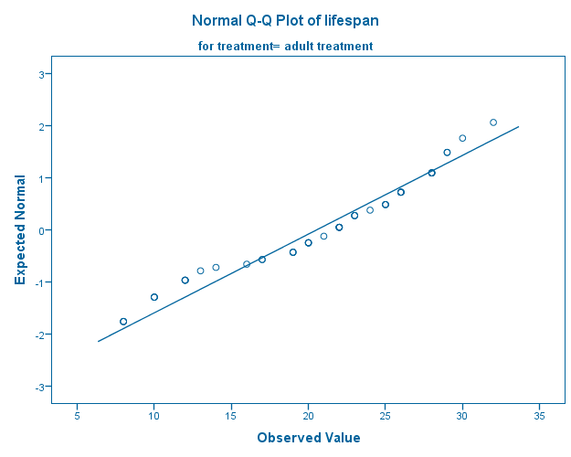

Detrended Normal Q-Q Plots  
Detrended Normal Q-Q Plots - treatment= water - August 24, 2018

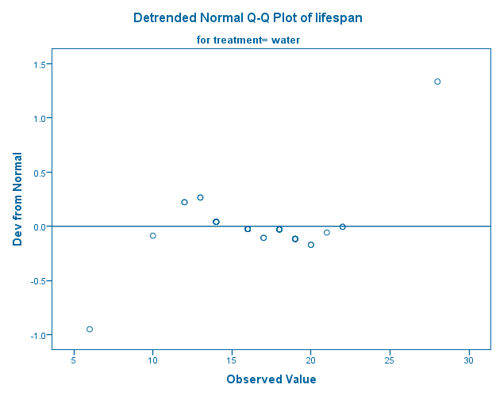

Detrended Normal Q-Q Plots  
Detrended Normal Q-Q Plots - treatment= treatment at both stages - August 24, 2018

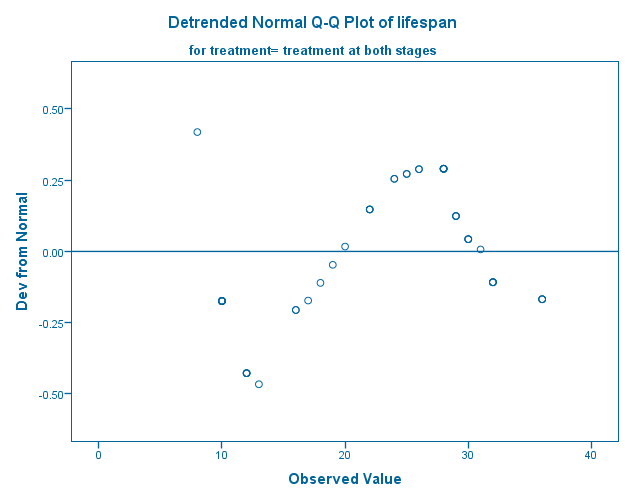

Detrended Normal Q-Q Plots  
Detrended Normal Q-Q Plots - treatment= larva treatment - August 24, 2018

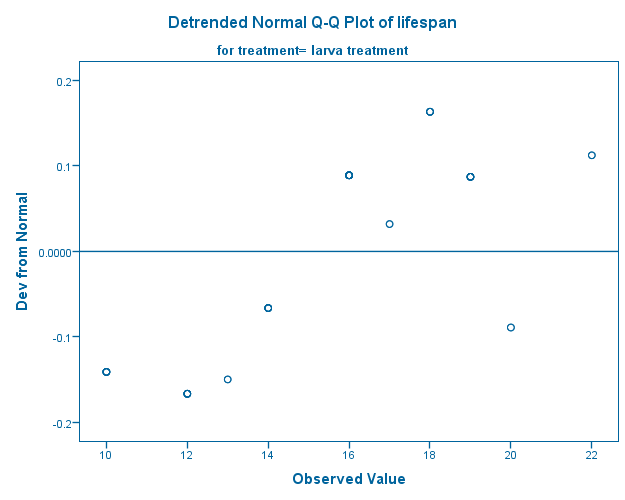

Detrended Normal Q-Q Plots  
Detrended Normal Q-Q Plots - treatment= adult treatment - August 24, 2018

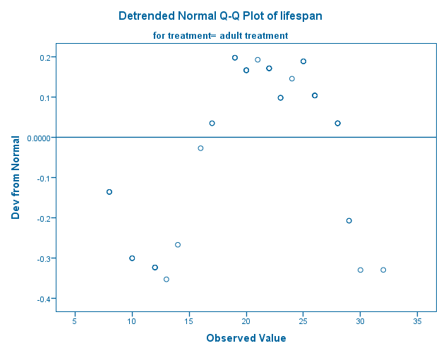

lifespan  
lifespan - Boxplot - August 24, 2018

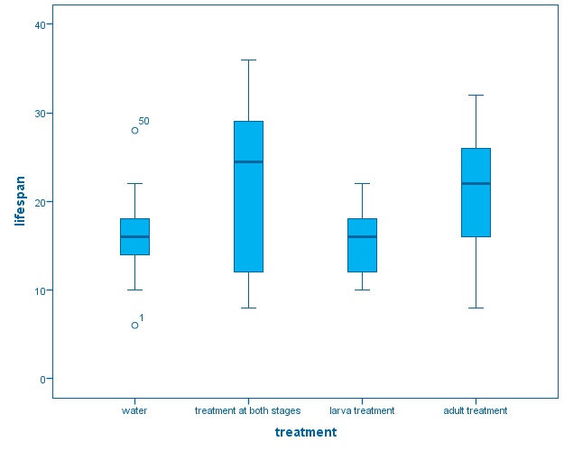

Log  
Log - Log - August 24, 2018

*Nonparametric Tests: Independent Samples.  
NPTESTS  
/INDEPENDENT TEST (lifespan) GROUP (treatment) KRUSKAL_WALLIS(COMPARE=PAIRWISE)  
/MISSING SCOPE=ANALYSIS USERMISSING=EXCLUDE  
/CRITERIA ALPHA=0.05 CILEVEL=95.

Nonparametric Tests  
Tables from the Model Viewer cannot be edited: Nonparametric Tests - Model Viewer - August 24, 2018

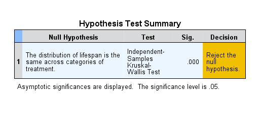

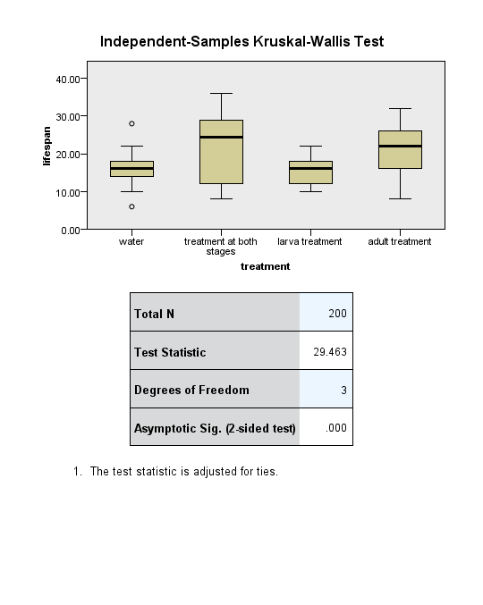

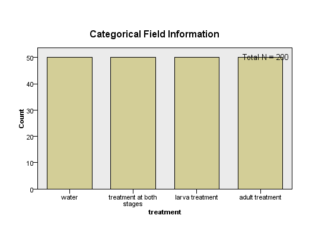

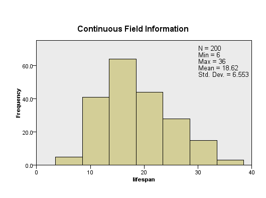

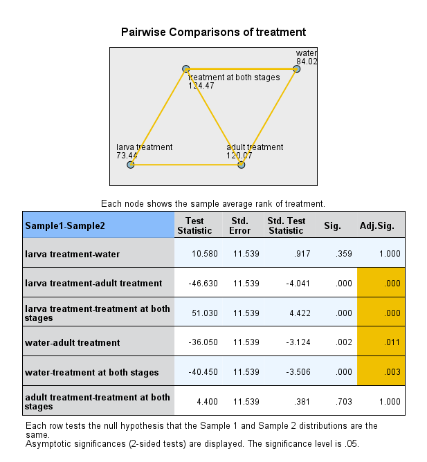

Log  
Log - Log - August 24, 2018

DATASET CLOSE DataSet3.  
DATASET CLOSE DataSet4.  
DATASET CLOSE DataSet5.  
DATASET CLOSE DataSet6.  
DATASET CLOSE DataSet7.  
GET  
FILE='C:\Users\Heather\Desktop\R CSV Data\Biometrics\SPSS files\SPSS files\HeightWeight.sav'.  
>Warning # 5281. Command name: GET FILE  
>SPSS Statistics is running in Unicode encoding mode. This file is encoded in  
>a locale-specific (code page) encoding. The defined width of any string  
>variables are automatically tripled in order to avoid possible data loss. You  
>can use ALTER TYPE to set the width of string variables to the width of the  
>longest observed value for each string variable.  
DATASET NAME DataSet9 WINDOW=FRONT.  
CORRELATIONS  
/VARIABLES=height weight  
/PRINT=TWOTAIL NOSIG  
/STATISTICS DESCRIPTIVES  
/MISSING=PAIRWISE.

Correlations  
Correlations - Active Dataset - August 24, 2018

[DataSet9] C:\Users\Heather\Desktop\R CSV Data\Biometrics\SPSS files\SPSS files\HeightWeight.sav

Correlations  
Correlations - Descriptive Statistics - August 24, 2018

Descriptive StatisticsDescriptive Statistics, table, 1 levels of column headers and 1 levels of row headers, table with 4 columns and 4 rows

|  | Mean | Std. Deviation | N |
| --- | --- | --- | --- |
| height | 68.7174 | 3.65929 | 92 |
| weight | 145.1522 | 23.73940 | 92 |

Correlations  
Correlations - Correlations - August 24, 2018

CorrelationsCorrelations, table, 1 levels of column headers and 2 levels of row headers, table with 4 columns and 9 rows

|  |  | height | weight |
| --- | --- | --- | --- |
| height | Pearson Correlation | 1 | .785** |
|  | Sig. (2-tailed) |  | .000 |
|  | N | 92 | 92 |
| weight | Pearson Correlation | .785** | 1 |
|  | Sig. (2-tailed) | .000 |  |
|  | N | 92 | 92 |

**. Correlation is significant at the 0.01 level (2-tailed).

Log  
Log - Log - August 24, 2018

SORT CASES BY sex.  
SPLIT FILE SEPARATE BY sex.  
CORRELATIONS  
/VARIABLES=height weight  
/PRINT=TWOTAIL NOSIG  
/STATISTICS DESCRIPTIVES  
/MISSING=PAIRWISE.

sex = male  
sex = male - Descriptive Statistics - August 24, 2018

Descriptive Statistics<sup>a</sup>Descriptive Statistics, table, 1 levels of column headers and 1 levels of row headers, table with 4 columns and 5 rows

|  | Mean | Std. Deviation | N |
| --- | --- | --- | --- |
| height | 70.7544 | 2.58278 | 57 |
| weight | 158.2632 | 18.63611 | 57 |

a. sex = male

sex = male  
sex = male - Correlations - August 24, 2018

Correlations<sup>a</sup>Correlations, table, 1 levels of column headers and 2 levels of row headers, table with 4 columns and 10 rows

|  |  | height | weight |
| --- | --- | --- | --- |
| height | Pearson Correlation | 1 | .604** |
|  | Sig. (2-tailed) |  | .000 |
|  | N | 57 | 57 |
| weight | Pearson Correlation | .604** | 1 |
|  | Sig. (2-tailed) | .000 |  |
|  | N | 57 | 57 |

**. Correlation is significant at the 0.01 level (2-tailed).  
a. sex = male

sex = female  
sex = female - Descriptive Statistics - August 24, 2018

Descriptive Statistics<sup>a</sup>Descriptive Statistics, table, 1 levels of column headers and 1 levels of row headers, table with 4 columns and 5 rows

|  | Mean | Std. Deviation | N |
| --- | --- | --- | --- |
| height | 65.4000 | 2.56260 | 35 |
| weight | 123.8000 | 13.37205 | 35 |

a. sex = female

sex = female  
sex = female - Correlations - August 24, 2018

Correlations<sup>a</sup>Correlations, table, 1 levels of column headers and 2 levels of row headers, table with 4 columns and 10 rows

|  |  | height | weight |
| --- | --- | --- | --- |
| height | Pearson Correlation | 1 | .494** |
|  | Sig. (2-tailed) |  | .003 |
|  | N | 35 | 35 |
| weight | Pearson Correlation | .494** | 1 |
|  | Sig. (2-tailed) | .003 |  |
|  | N | 35 | 35 |

**. Correlation is significant at the 0.01 level (2-tailed).  
a. sex = female

Log  
Log - Log - August 24, 2018

SPLIT FILE OFF.  
* Chart Builder.  
GGRAPH  
/GRAPHDATASET NAME="graphdataset" VARIABLES=height weight MISSING=LISTWISE REPORTMISSING=NO  
/GRAPHSPEC SOURCE=INLINE.  
BEGIN GPL  
SOURCE: s=userSource(id("graphdataset"))  
DATA: height=col(source(s), name("height"))  
DATA: weight=col(source(s), name("weight"))  
GUIDE: axis(dim(1), label("height"))  
GUIDE: axis(dim(2), label("weight"))  
ELEMENT: point(position(height*weight))  
END GPL.

GGraph  
GGraph - Graph - August 24, 2018

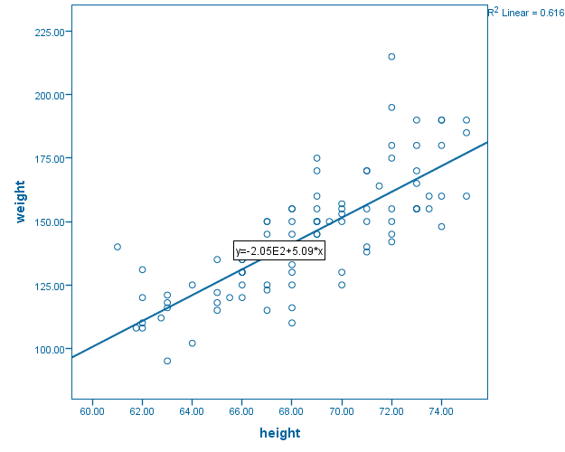

Log  
Log - Log - August 24, 2018

GET  
FILE='C:\Users\Heather\Desktop\R CSV Data\Biometrics\SPSS files\SPSS files\chocolate.sav'.  
DATASET NAME DataSet10 WINDOW=FRONT.  
* Chart Builder.  
GGRAPH  
/GRAPHDATASET NAME="graphdataset" VARIABLES=chocolateConsumption nobelPrizesper100million  
MISSING=LISTWISE REPORTMISSING=NO  
/GRAPHSPEC SOURCE=INLINE.  
BEGIN GPL  
SOURCE: s=userSource(id("graphdataset"))  
DATA: chocolateConsumption=col(source(s), name("chocolateConsumption"))  
DATA: nobelPrizesper100million=col(source(s), name("nobelPrizesper100million"))  
GUIDE: axis(dim(1), label("chocolateConsumption"))  
GUIDE: axis(dim(2), label("nobelPrizesper100million"))  
ELEMENT: point(position(chocolateConsumption*nobelPrizesper100million))  
END GPL.

GGraph  
GGraph - Active Dataset - August 24, 2018

[DataSet10] C:\Users\Heather\Desktop\R CSV Data\Biometrics\SPSS files\SPSS files\chocolate.sav

GGraph  
GGraph - Graph - August 24, 2018

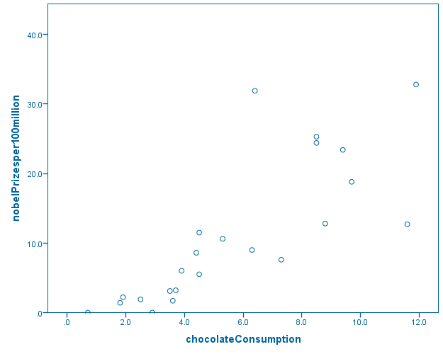

Log  
Log - Log - August 24, 2018

NONPAR CORR  
/VARIABLES=chocolateConsumption nobelPrizesper100million  
/PRINT=SPEARMAN TWOTAIL NOSIG  
/MISSING=PAIRWISE.

Nonparametric Correlations  
Nonparametric Correlations - Correlations - August 24, 2018

CorrelationsCorrelations, table, 1 levels of column headers and 3 levels of row headers, table with 5 columns and 9 rows

|  |  |  | chocolateConsumption | nobelPrizesper100million |
| --- | --- | --- | --- | --- |
| Spearman's rho | chocolateConsumption | Correlation Coefficient | 1.000 | .900** |
|  |  | Sig. (2-tailed) | . | .000 |
|  |  | N | 23 | 23 |
|  | nobelPrizesper100million | Correlation Coefficient | .900** | 1.000 |
|  |  | Sig. (2-tailed) | .000 | . |
|  |  | N | 23 | 23 |

**. Correlation is significant at the 0.01 level (2-tailed).

Log  
Log - Log - August 24, 2018

GET  
FILE='C:\Users\Heather\Desktop\R CSV Data\Biometrics\SPSS files\SPSS files\appendixd.sav'.  
>Warning # 5281. Command name: GET FILE  
>SPSS Statistics is running in Unicode encoding mode. This file is encoded in  
>a locale-specific (code page) encoding. The defined width of any string  
>variables are automatically tripled in order to avoid possible data loss. You  
>can use ALTER TYPE to set the width of string variables to the width of the  
>longest observed value for each string variable.  
DATASET NAME DataSet11 WINDOW=FRONT.  
CORRELATIONS  
/VARIABLES=addsc iq gpa engg  
/PRINT=TWOTAIL NOSIG  
/MISSING=PAIRWISE.

Correlations  
Correlations - Active Dataset - August 24, 2018

[DataSet11] C:\Users\Heather\Desktop\R CSV Data\Biometrics\SPSS files\SPSS files\appendixd.sav

Correlations  
Correlations - Correlations - August 24, 2018

CorrelationsCorrelations, table, 1 levels of column headers and 2 levels of row headers, table with 6 columns and 15 rows

|  |  | ADD score | IQ score | GPA in 9th grade | Grade in 9th grade English class |
| --- | --- | --- | --- | --- | --- |
| ADD score | Pearson Correlation | 1 | -.632** | -.615** | -.478** |
|  | Sig. (2-tailed) |  | .000 | .000 | .000 |
|  | N | 88 | 88 | 88 | 88 |
| IQ score | Pearson Correlation | -.632** | 1 | .497** | .370** |
|  | Sig. (2-tailed) | .000 |  | .000 | .000 |
|  | N | 88 | 88 | 88 | 88 |
| GPA in 9th grade | Pearson Correlation | -.615** | .497** | 1 | .839** |
|  | Sig. (2-tailed) | .000 | .000 |  | .000 |
|  | N | 88 | 88 | 88 | 88 |
| Grade in 9th grade English class | Pearson Correlation | -.478** | .370** | .839** | 1 |
|  | Sig. (2-tailed) | .000 | .000 | .000 |  |
|  | N | 88 | 88 | 88 | 88 |

**. Correlation is significant at the 0.01 level (2-tailed).

Log  
Log - Log - August 24, 2018

GET  
FILE='C:\Users\Heather\Desktop\R CSV Data\Biometrics\SPSS files\SPSS files\Lions ages.sav'.  
>Warning # 5281. Command name: GET FILE  
>SPSS Statistics is running in Unicode encoding mode. This file is encoded in  
>a locale-specific (code page) encoding. The defined width of any string  
>variables are automatically tripled in order to avoid possible data loss. You  
>can use ALTER TYPE to set the width of string variables to the width of the  
>longest observed value for each string variable.  
DATASET NAME DataSet12 WINDOW=FRONT.  
* Chart Builder.  
GGRAPH  
/GRAPHDATASET NAME="graphdataset" VARIABLES=proportion.black[name="proportion_black"] age  
MISSING=LISTWISE REPORTMISSING=NO  
/GRAPHSPEC SOURCE=INLINE.  
BEGIN GPL  
SOURCE: s=userSource(id("graphdataset"))  
DATA: proportion_black=col(source(s), name("proportion_black"))  
DATA: age=col(source(s), name("age"))  
GUIDE: axis(dim(1), label("proportion.black"))  
GUIDE: axis(dim(2), label("age"))  
ELEMENT: point(position(proportion_black*age))  
END GPL.

GGraph  
GGraph - Active Dataset - August 24, 2018

[DataSet12] C:\Users\Heather\Desktop\R CSV Data\Biometrics\SPSS files\SPSS files\Lions ages.sav

GGraph  
GGraph - Graph - August 24, 2018

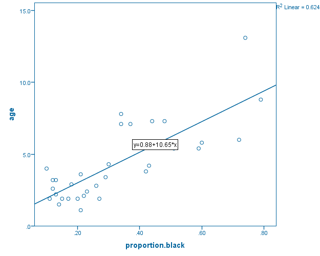

Log  
Log - Log - August 24, 2018

REGRESSION  
/DESCRIPTIVES MEAN STDDEV CORR SIG N  
/MISSING LISTWISE  
/STATISTICS COEFF OUTS CI(95) R ANOVA  
/CRITERIA=PIN(.05) POUT(.10)  
/NOORIGIN  
/DEPENDENT age  
/METHOD=ENTER proportion.black  
/SAVE PRED RESID.

Regression  
Regression - Descriptive Statistics - August 24, 2018

Descriptive StatisticsDescriptive Statistics, table, 1 levels of column headers and 1 levels of row headers, table with 4 columns and 4 rows

|  | Mean | Std. Deviation | N |
| --- | --- | --- | --- |
| age | 4.309 | 2.6766 | 32 |
| proportion.black | .3222 | .19856 | 32 |

Regression  
Regression - Correlations - August 24, 2018

CorrelationsCorrelations, table, 1 levels of column headers and 2 levels of row headers, table with 4 columns and 8 rows

|  |  | age | proportion.black |
| --- | --- | --- | --- |
| Pearson Correlation | age | 1.000 | .790 |
|  | proportion.black | .790 | 1.000 |
| Sig. (1-tailed) | age | . | .000 |
|  | proportion.black | .000 | . |
| N | age | 32 | 32 |
|  | proportion.black | 32 | 32 |

Regression  
Regression - Variables Entered/Removed - August 24, 2018

Variables Entered/Removed<sup>a</sup>Variables Entered/Removed, table, 1 levels of column headers and 1 levels of row headers, table with 4 columns and 5 rows

| Model | Variables Entered | Variables Removed | Method |
| --- | --- | --- | --- |
| 1 | proportion.black<sup>b</sup> | . | Enter |

a. Dependent Variable: age  
b. All requested variables entered.

Regression  
Regression - Model Summary - August 24, 2018

Model Summary<sup>b</sup>Model Summary, table, 1 levels of column headers and 1 levels of row headers, table with 5 columns and 5 rows

| Model | R | R Square | Adjusted R Square | Std. Error of the Estimate |
| --- | --- | --- | --- | --- |
| 1 | .790<sup>a</sup> | .624 | .611 | 1.6688 |

a. Predictors: (Constant), proportion.black  
b. Dependent Variable: age

Regression  
Regression - ANOVA - August 24, 2018

ANOVA<sup>a</sup>ANOVA, table, 1 levels of column headers and 2 levels of row headers, table with 7 columns and 7 rows

| Model |  | Sum of Squares | df | Mean Square | F | Sig. |
| --- | --- | --- | --- | --- | --- | --- |
| 1 | Regression | 138.544 | 1 | 138.544 | 49.751 | .000<sup>b</sup> |
|  | Residual | 83.543 | 30 | 2.785 |  |  |
|  | Total | 222.087 | 31 |  |  |  |

a. Dependent Variable: age  
b. Predictors: (Constant), proportion.black

Regression  
Regression - Coefficients - August 24, 2018

Coefficients<sup>a</sup>Coefficients, table, 2 levels of column headers and 2 levels of row headers, table with 9 columns and 6 rows

| Model |  | Unstandardized Coefficients |  | Standardized Coefficients | t | Sig. | 95.0% Confidence Interval for B |  |
| --- | --- | --- | --- | --- | --- | --- | --- | --- |
|  |  | B | Std. Error | Beta |  |  | Lower Bound | Upper Bound |
| 1 | (Constant) | .879 | .569 |  | 1.545 | .133 | -.283 | 2.041 |
|  | proportion.black | 10.647 | 1.510 | .790 | 7.053 | .000 | 7.564 | 13.730 |

a. Dependent Variable: age

Regression  
Regression - Residuals Statistics - August 24, 2018

Residuals Statistics<sup>a</sup>Residuals Statistics, table, 1 levels of column headers and 1 levels of row headers, table with 6 columns and 7 rows

|  | Minimum | Maximum | Mean | Std. Deviation | N |
| --- | --- | --- | --- | --- | --- |
| Predicted Value | 1.944 | 9.290 | 4.309 | 2.1140 | 32 |
| Residual | -2.5449 | 4.3421 | .0000 | 1.6416 | 32 |
| Std. Predicted Value | -1.119 | 2.356 | .000 | 1.000 | 32 |
| Std. Residual | -1.525 | 2.602 | .000 | .984 | 32 |

a. Dependent Variable: age

Log  
Log - Log - August 24, 2018

EXAMINE VARIABLES=RES_1  
/PLOT BOXPLOT HISTOGRAM  
/COMPARE GROUPS  
/STATISTICS DESCRIPTIVES  
/CINTERVAL 95  
/MISSING LISTWISE  
/NOTOTAL.

Explore  
Explore - Case Processing Summary - August 24, 2018

Case Processing SummaryCase Processing Summary, table, 3 levels of column headers and 1 levels of row headers, table with 7 columns and 5 rows

|  | Cases |  |  |  |  |  |
| --- | --- | --- | --- | --- | --- | --- |
|  | Valid |  | Missing |  | Total |  |
|  | N | Percent | N | Percent | N | Percent |
| Unstandardized Residual | 32 | 100.0% | 0 | 0.0% | 32 | 100.0% |

Explore  
Explore - Descriptives - August 24, 2018

DescriptivesDescriptives, table, 1 levels of column headers and 3 levels of row headers, table with 5 columns and 15 rows

|  |  |  | Statistic | Std. Error |
| --- | --- | --- | --- | --- |
| Unstandardized Residual | Mean |  | .0000000 | .29020156 |
|  | 95% Confidence Interval for Mean | Lower Bound | -.5918700 |  |
|  |  | Upper Bound | .5918700 |  |
|  | 5% Trimmed Mean |  | -.0891957 |  |
|  | Median |  | -.5284507 |  |
|  | Variance |  | 2.695 |  |
|  | Std. Deviation |  | 1.64162792 |  |
|  | Minimum |  | -2.54493 |  |
|  | Maximum |  | 4.34213 |  |
|  | Range |  | 6.88706 |  |
|  | Interquartile Range |  | 2.13486 |  |
|  | Skewness |  | .884 | .414 |
|  | Kurtosis |  | .342 | .809 |

Unstandardized Residual  
Unstandardized Residual - Histogram - August 24, 2018

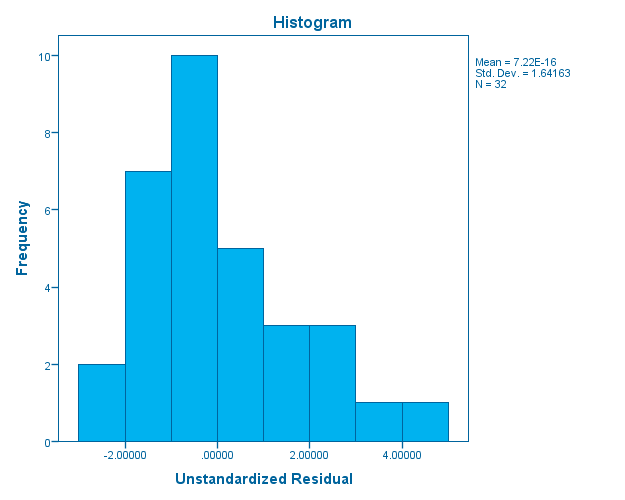

Unstandardized Residual  
Unstandardized Residual - Boxplot - August 24, 2018

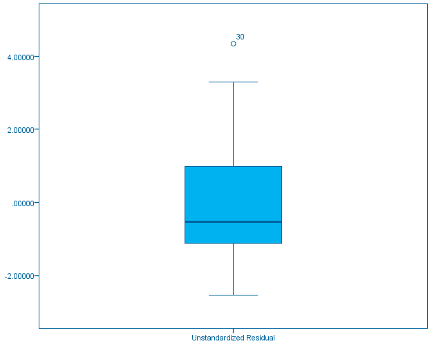

Log  
Log - Log - August 24, 2018

GET  
FILE='C:\Users\Heather\Desktop\R CSV Data\Biometrics\SPSS files\SPSS files\mammals.sav'.  
DATASET NAME DataSet13 WINDOW=FRONT.  
* Chart Builder.  
GGRAPH  
/GRAPHDATASET NAME="graphdataset" VARIABLES=bodymasskg brainmassg MISSING=LISTWISE  
REPORTMISSING=NO  
/GRAPHSPEC SOURCE=INLINE.  
BEGIN GPL  
SOURCE: s=userSource(id("graphdataset"))  
DATA: bodymasskg=col(source(s), name("bodymasskg"))  
DATA: brainmassg=col(source(s), name("brainmassg"))  
GUIDE: axis(dim(1), label("bodymasskg"))  
GUIDE: axis(dim(2), label("brainmassg"))  
ELEMENT: point(position(bodymasskg*brainmassg))  
END GPL.

GGraph  
GGraph - Active Dataset - August 24, 2018

[DataSet13] C:\Users\Heather\Desktop\R CSV Data\Biometrics\SPSS files\SPSS files\mammals.sav

GGraph  
GGraph - Graph - August 24, 2018

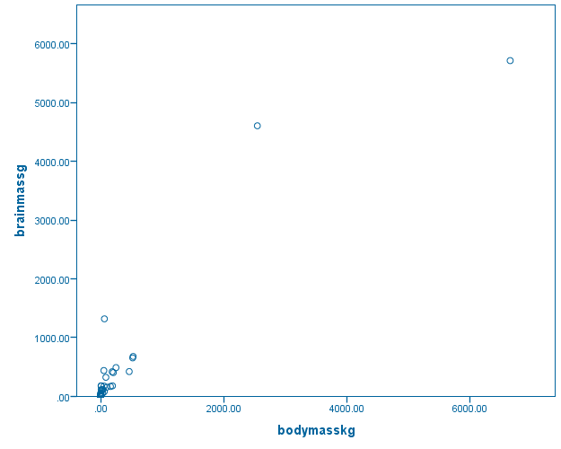

Log  
Log - Log - August 24, 2018

COMPUTE LnBodyMass=LN(bodymasskg).  
EXECUTE.  
COMPUTE LnBrainMass=LN(brainmassg).  
EXECUTE.  
* Chart Builder.  
GGRAPH  
/GRAPHDATASET NAME="graphdataset" VARIABLES=LnBodyMass LnBrainMass MISSING=LISTWISE  
REPORTMISSING=NO  
/GRAPHSPEC SOURCE=INLINE.  
BEGIN GPL  
SOURCE: s=userSource(id("graphdataset"))  
DATA: LnBodyMass=col(source(s), name("LnBodyMass"))  
DATA: LnBrainMass=col(source(s), name("LnBrainMass"))  
GUIDE: axis(dim(1), label("LnBodyMass"))  
GUIDE: axis(dim(2), label("LnBrainMass"))  
ELEMENT: point(position(LnBodyMass*LnBrainMass))  
END GPL.

GGraph  
GGraph - Graph - August 24, 2018

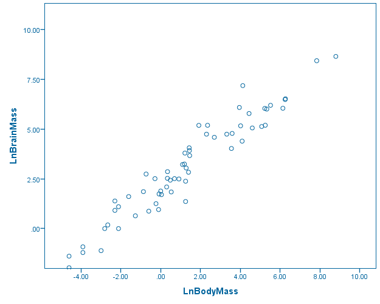

Log  
Log - Log - August 24, 2018

REGRESSION  
/DESCRIPTIVES MEAN STDDEV CORR SIG N  
/MISSING LISTWISE  
/STATISTICS COEFF OUTS CI(95) R ANOVA  
/CRITERIA=PIN(.05) POUT(.10)  
/NOORIGIN  
/DEPENDENT LnBrainMass  
/METHOD=ENTER LnBodyMass  
/SAVE PRED RESID.

Regression  
Regression - Descriptive Statistics - August 24, 2018

Descriptive StatisticsDescriptive Statistics, table, 1 levels of column headers and 1 levels of row headers, table with 4 columns and 4 rows

|  | Mean | Std. Deviation | N |
| --- | --- | --- | --- |
| LnBrainMass | 3.1402 | 2.44651 | 62 |
| LnBodyMass | 1.3426 | 3.10963 | 62 |

Regression  
Regression - Correlations - August 24, 2018

CorrelationsCorrelations, table, 1 levels of column headers and 2 levels of row headers, table with 4 columns and 8 rows

|  |  | LnBrainMass | LnBodyMass |
| --- | --- | --- | --- |
| Pearson Correlation | LnBrainMass | 1.000 | .959 |
|  | LnBodyMass | .959 | 1.000 |
| Sig. (1-tailed) | LnBrainMass | . | .000 |
|  | LnBodyMass | .000 | . |
| N | LnBrainMass | 62 | 62 |
|  | LnBodyMass | 62 | 62 |

Regression  
Regression - Variables Entered/Removed - August 24, 2018

Variables Entered/Removed<sup>a</sup>Variables Entered/Removed, table, 1 levels of column headers and 1 levels of row headers, table with 4 columns and 5 rows

| Model | Variables Entered | Variables Removed | Method |
| --- | --- | --- | --- |
| 1 | LnBodyMass<sup>b</sup> | . | Enter |

a. Dependent Variable: LnBrainMass  
b. All requested variables entered.

Regression  
Regression - Model Summary - August 24, 2018

Model Summary<sup>b</sup>Model Summary, table, 1 levels of column headers and 1 levels of row headers, table with 5 columns and 5 rows

| Model | R | R Square | Adjusted R Square | Std. Error of the Estimate |
| --- | --- | --- | --- | --- |
| 1 | .959<sup>a</sup> | .920 | .918 | .69900 |

a. Predictors: (Constant), LnBodyMass  
b. Dependent Variable: LnBrainMass

Regression  
Regression - ANOVA - August 24, 2018

ANOVA<sup>a</sup>ANOVA, table, 1 levels of column headers and 2 levels of row headers, table with 7 columns and 7 rows

| Model |  | Sum of Squares | df | Mean Square | F | Sig. |
| --- | --- | --- | --- | --- | --- | --- |
| 1 | Regression | 335.795 | 1 | 335.795 | 687.260 | .000<sup>b</sup> |
|  | Residual | 29.316 | 60 | .489 |  |  |
|  | Total | 365.111 | 61 |  |  |  |

a. Dependent Variable: LnBrainMass  
b. Predictors: (Constant), LnBodyMass

Regression  
Regression - Coefficients - August 24, 2018

Coefficients<sup>a</sup>Coefficients, table, 2 levels of column headers and 2 levels of row headers, table with 9 columns and 6 rows

| Model |  | Unstandardized Coefficients |  | Standardized Coefficients | t | Sig. | 95.0% Confidence Interval for B |  |
| --- | --- | --- | --- | --- | --- | --- | --- | --- |
|  |  | B | Std. Error | Beta |  |  | Lower Bound | Upper Bound |
| 1 | (Constant) | 2.127 | .097 |  | 21.971 | .000 | 1.934 | 2.321 |
|  | LnBodyMass | .755 | .029 | .959 | 26.216 | .000 | .697 | .812 |

a. Dependent Variable: LnBrainMass

Regression  
Regression - Residuals Statistics - August 24, 2018

Residuals Statistics<sup>a</sup>Residuals Statistics, table, 1 levels of column headers and 1 levels of row headers, table with 6 columns and 7 rows

|  | Minimum | Maximum | Mean | Std. Deviation | N |
| --- | --- | --- | --- | --- | --- |
| Predicted Value | -1.3474 | 8.7691 | 3.1402 | 2.34624 | 62 |
| Residual | -1.71143 | 1.94425 | .00000 | .69325 | 62 |
| Std. Predicted Value | -1.913 | 2.399 | .000 | 1.000 | 62 |
| Std. Residual | -2.448 | 2.781 | .000 | .992 | 62 |

a. Dependent Variable: LnBrainMass

Log  
Log - Log - August 24, 2018

GET  
FILE='C:\Users\Heather\Desktop\R CSV Data\Biometrics\SPSS files\SPSS files\telomeres.sav'.  
DATASET NAME DataSet14 WINDOW=FRONT.  
* Chart Builder.  
GGRAPH  
/GRAPHDATASET NAME="graphdataset" VARIABLES=father.telomere.length[name="father_telomere_length"]  
offspring.telomere.length[name="offspring_telomere_length"] MISSING=LISTWISE REPORTMISSING=NO  
/GRAPHSPEC SOURCE=INLINE.  
BEGIN GPL  
SOURCE: s=userSource(id("graphdataset"))  
DATA: father_telomere_length=col(source(s), name("father_telomere_length"))  
DATA: offspring_telomere_length=col(source(s), name("offspring_telomere_length"))  
GUIDE: axis(dim(1), label("father.telomere.length"))  
GUIDE: axis(dim(2), label("offspring.telomere.length"))  
ELEMENT: point(position(father_telomere_length*offspring_telomere_length))  
END GPL.

GGraph  
GGraph - Active Dataset - August 24, 2018

[DataSet14] C:\Users\Heather\Desktop\R CSV Data\Biometrics\SPSS files\SPSS files\telomeres.sav

GGraph  
GGraph - Graph - August 24, 2018

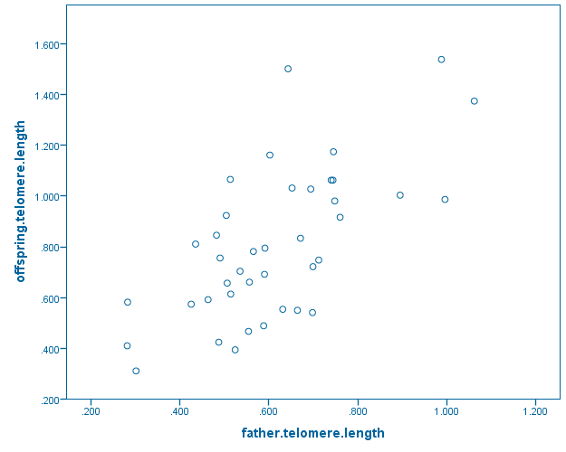

Log  
Log - Log - August 24, 2018

REGRESSION  
/DESCRIPTIVES MEAN STDDEV CORR SIG N  
/MISSING LISTWISE  
/STATISTICS COEFF OUTS CI(95) R ANOVA  
/CRITERIA=PIN(.05) POUT(.10)  
/NOORIGIN  
/DEPENDENT offspring.telomere.length  
/METHOD=ENTER father.telomere.length  
/SAVE PRED RESID.

Regression  
Regression - Descriptive Statistics - August 24, 2018

Descriptive StatisticsDescriptive Statistics, table, 1 levels of column headers and 1 levels of row headers, table with 4 columns and 4 rows

|  | Mean | Std. Deviation | N |
| --- | --- | --- | --- |
| offspring.telomere.length | .80820 | .296931 | 40 |
| father.telomere.length | .61325 | .176971 | 40 |

Regression  
Regression - Correlations - August 24, 2018

CorrelationsCorrelations, table, 1 levels of column headers and 2 levels of row headers, table with 4 columns and 8 rows

|  |  | offspring.telomere.length | father.telomere.length |
| --- | --- | --- | --- |
| Pearson Correlation | offspring.telomere.length | 1.000 | .667 |
|  | father.telomere.length | .667 | 1.000 |
| Sig. (1-tailed) | offspring.telomere.length | . | .000 |
|  | father.telomere.length | .000 | . |
| N | offspring.telomere.length | 40 | 40 |
|  | father.telomere.length | 40 | 40 |

Regression  
Regression - Variables Entered/Removed - August 24, 2018

Variables Entered/Removed<sup>a</sup>Variables Entered/Removed, table, 1 levels of column headers and 1 levels of row headers, table with 4 columns and 5 rows

| Model | Variables Entered | Variables Removed | Method |
| --- | --- | --- | --- |
| 1 | father.telomere.length<sup>b</sup> | . | Enter |

a. Dependent Variable: offspring.telomere.length  
b. All requested variables entered.

Regression  
Regression - Model Summary - August 24, 2018

Model Summary<sup>b</sup>Model Summary, table, 1 levels of column headers and 1 levels of row headers, table with 5 columns and 5 rows

| Model | R | R Square | Adjusted R Square | Std. Error of the Estimate |
| --- | --- | --- | --- | --- |
| 1 | .667<sup>a</sup> | .445 | .431 | .224036 |

a. Predictors: (Constant), father.telomere.length  
b. Dependent Variable: offspring.telomere.length

Regression  
Regression - ANOVA - August 24, 2018

ANOVA<sup>a</sup>ANOVA, table, 1 levels of column headers and 2 levels of row headers, table with 7 columns and 7 rows

| Model |  | Sum of Squares | df | Mean Square | F | Sig. |
| --- | --- | --- | --- | --- | --- | --- |
| 1 | Regression | 1.531 | 1 | 1.531 | 30.508 | .000<sup>b</sup> |
|  | Residual | 1.907 | 38 | .050 |  |  |
|  | Total | 3.439 | 39 |  |  |  |

a. Dependent Variable: offspring.telomere.length  
b. Predictors: (Constant), father.telomere.length

Regression  
Regression - Coefficients - August 24, 2018

Coefficients<sup>a</sup>Coefficients, table, 2 levels of column headers and 2 levels of row headers, table with 9 columns and 6 rows

| Model |  | Unstandardized Coefficients |  | Standardized Coefficients | t | Sig. | 95.0% Confidence Interval for B |  |
| --- | --- | --- | --- | --- | --- | --- | --- | --- |
|  |  | B | Std. Error | Beta |  |  | Lower Bound | Upper Bound |
| 1 | (Constant) | .122 | .129 |  | .940 | .353 | -.140 | .383 |
|  | father.telomere.length | 1.120 | .203 | .667 | 5.523 | .000 | .709 | 1.530 |

a. Dependent Variable: offspring.telomere.length

Regression  
Regression - Residuals Statistics - August 24, 2018

Residuals Statistics<sup>a</sup>Residuals Statistics, table, 1 levels of column headers and 1 levels of row headers, table with 6 columns and 7 rows

|  | Minimum | Maximum | Mean | Std. Deviation | N |
| --- | --- | --- | --- | --- | --- |
| Predicted Value | .43619 | 1.31065 | .80820 | .198148 | 40 |
| Residual | -.362092 | .660490 | .000000 | .221146 | 40 |
| Std. Predicted Value | -1.877 | 2.536 | .000 | 1.000 | 40 |
| Std. Residual | -1.616 | 2.948 | .000 | .987 | 40 |

a. Dependent Variable: offspring.telomere.length

Log  
Log - Log - August 24, 2018

GET  
FILE='C:\Users\Heather\Desktop\R CSV Data\Biometrics\SPSS files\SPSS files\symptoms and stress.sav'.  
DATASET NAME DataSet15 WINDOW=FRONT.  
* Chart Builder.  
GGRAPH  
/GRAPHDATASET NAME="graphdataset" VARIABLES=stress symptoms MISSING=LISTWISE REPORTMISSING=NO  
/GRAPHSPEC SOURCE=INLINE.  
BEGIN GPL  
SOURCE: s=userSource(id("graphdataset"))  
DATA: stress=col(source(s), name("stress"))  
DATA: symptoms=col(source(s), name("symptoms"))  
GUIDE: axis(dim(1), label("stress"))  
GUIDE: axis(dim(2), label("symptoms"))  
ELEMENT: point(position(stress*symptoms))  
END GPL.

GGraph  
GGraph - Active Dataset - August 24, 2018

[DataSet15] C:\Users\Heather\Desktop\R CSV Data\Biometrics\SPSS files\SPSS files\symptoms and stress.sav

GGraph  
GGraph - Graph - August 24, 2018

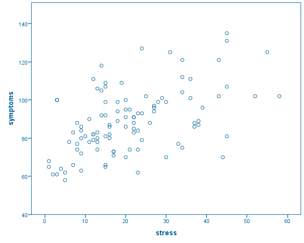

Log  
Log - Log - August 24, 2018

REGRESSION  
/DESCRIPTIVES MEAN STDDEV CORR SIG N  
/MISSING LISTWISE  
/STATISTICS COEFF OUTS CI(95) R ANOVA  
/CRITERIA=PIN(.05) POUT(.10)  
/NOORIGIN  
/DEPENDENT symptoms  
/METHOD=ENTER stress  
/SAVE PRED RESID.

Regression  
Regression - Descriptive Statistics - August 24, 2018

Descriptive StatisticsDescriptive Statistics, table, 1 levels of column headers and 1 levels of row headers, table with 4 columns and 4 rows

|  | Mean | Std. Deviation | N |
| --- | --- | --- | --- |
| symptoms | 88.90 | 16.921 | 104 |
| stress | 21.13 | 12.797 | 104 |

Regression  
Regression - Correlations - August 24, 2018

CorrelationsCorrelations, table, 1 levels of column headers and 2 levels of row headers, table with 4 columns and 8 rows

|  |  | symptoms | stress |
| --- | --- | --- | --- |
| Pearson Correlation | symptoms | 1.000 | .520 |
|  | stress | .520 | 1.000 |
| Sig. (1-tailed) | symptoms | . | .000 |
|  | stress | .000 | . |
| N | symptoms | 104 | 104 |
|  | stress | 104 | 104 |

Regression  
Regression - Variables Entered/Removed - August 24, 2018

Variables Entered/Removed<sup>a</sup>Variables Entered/Removed, table, 1 levels of column headers and 1 levels of row headers, table with 4 columns and 5 rows

| Model | Variables Entered | Variables Removed | Method |
| --- | --- | --- | --- |
| 1 | stress<sup>b</sup> | . | Enter |

a. Dependent Variable: symptoms  
b. All requested variables entered.

Regression  
Regression - Model Summary - August 24, 2018

Model Summary<sup>b</sup>Model Summary, table, 1 levels of column headers and 1 levels of row headers, table with 5 columns and 5 rows

| Model | R | R Square | Adjusted R Square | Std. Error of the Estimate |
| --- | --- | --- | --- | --- |
| 1 | .520<sup>a</sup> | .271 | .264 | 14.519 |

a. Predictors: (Constant), stress  
b. Dependent Variable: symptoms

Regression  
Regression - ANOVA - August 24, 2018

ANOVA<sup>a</sup>ANOVA, table, 1 levels of column headers and 2 levels of row headers, table with 7 columns and 7 rows

| Model |  | Sum of Squares | df | Mean Square | F | Sig. |
| --- | --- | --- | --- | --- | --- | --- |
| 1 | Regression | 7988.882 | 1 | 7988.882 | 37.897 | .000<sup>b</sup> |
|  | Residual | 21502.156 | 102 | 210.805 |  |  |
|  | Total | 29491.038 | 103 |  |  |  |

a. Dependent Variable: symptoms  
b. Predictors: (Constant), stress

Regression  
Regression - Coefficients - August 24, 2018

Coefficients<sup>a</sup>Coefficients, table, 2 levels of column headers and 2 levels of row headers, table with 9 columns and 6 rows

| Model |  | Unstandardized Coefficients |  | Standardized Coefficients | t | Sig. | 95.0% Confidence Interval for B |  |
| --- | --- | --- | --- | --- | --- | --- | --- | --- |
|  |  | B | Std. Error | Beta |  |  | Lower Bound | Upper Bound |
| 1 | (Constant) | 74.365 | 2.758 |  | 26.968 | .000 | 68.896 | 79.835 |
|  | stress | .688 | .112 | .520 | 6.156 | .000 | .466 | .910 |

a. Dependent Variable: symptoms

Regression  
Regression - Residuals Statistics - August 24, 2018

Residuals Statistics<sup>a</sup>Residuals Statistics, table, 1 levels of column headers and 1 levels of row headers, table with 6 columns and 7 rows

|  | Minimum | Maximum | Mean | Std. Deviation | N |
| --- | --- | --- | --- | --- | --- |
| Predicted Value | 75.05 | 114.28 | 88.90 | 8.807 | 104 |
| Residual | -34.647 | 36.118 | .000 | 14.448 | 104 |
| Std. Predicted Value | -1.573 | 2.882 | .000 | 1.000 | 104 |
| Std. Residual | -2.386 | 2.488 | .000 | .995 | 104 |

a. Dependent Variable: symptoms

[output not shown]

[output not shown]

[output not shown]

[output not shown]

[output not shown]

[output not shown]